# dimonds

```
                                             ANALYSIS OF DIAMONDS DATA
```

```
                                                     INDEX
```

1. IMPORTING LIBRARIES
2. LOADING DATA
3. DATA PREPROCESING
4. DATA VISUALIZATION
5. MODEL BUILDING

```
                                                   LIBRARIES
```

IMPORING LIBRARIES

import pandas as pd import matplotlib.pyplot as plt from sklearn.preprocessing import LabelEncoder from sklearn.linear_model import LinearRegression from sklearn.metrics import mean_squared_error, r2_score from sklearn.tree import DecisionTreeRegressor

```
                                                  LOADING DATA
```

The 4 Cs of Diamonds:-

1. Carat

Represents the weight of the diamond Range: 0.2 to 5.01 1 carat = 0.2 grams Most objective of all diamond characteristics

2. Cut

Describes the quality of the diamond’s cut Affects how well the diamond reflects light

Categories: Fair Good Very Good Premium Ideal

3. Color

Indicates the color quality of the diamond Graded from: D (best, colorless) → J (worst) Colorless diamonds are more valuable 4. Clarity

Measures internal inclusions and external blemishes Categories (worst → best): I1 SI2, SI1 VS2, VS1 VVS2, VVS1 IF Physical Measurements

5. Depth Total depth percentage Calculated as: (z / mean(x, y)) × 100
6. Table Width of the top of the diamond relative to its widest point Expressed as a percentage
7. Dimensions x: Length (mm) y: Width (mm) z: Depth (mm)

```python
import pandas as pd
df=pd.read_csv("diamonds.csv")
print(df)
```

```
       carat        cut color clarity  depth  table  price     x     y     z
0       0.23      Ideal     E     SI2   61.5   55.0    326  3.95  3.98  2.43
1       0.21    Premium     E     SI1   59.8   61.0    326  3.89  3.84  2.31
2       0.23       Good     E     VS1   56.9   65.0    327  4.05  4.07  2.31
3       0.29    Premium     I     VS2   62.4   58.0    334  4.20  4.23  2.63
4       0.31       Good     J     SI2   63.3   58.0    335  4.34  4.35  2.75
...      ...        ...   ...     ...    ...    ...    ...   ...   ...   ...
53935   0.72      Ideal     D     SI1   60.8   57.0   2757  5.75  5.76  3.50
53936   0.72       Good     D     SI1   63.1   55.0   2757  5.69  5.75  3.61
53937   0.70  Very Good     D     SI1   62.8   60.0   2757  5.66  5.68  3.56
53938   0.86    Premium     H     SI2   61.0   58.0   2757  6.15  6.12  3.74
53939   0.75      Ideal     D     SI2   62.2   55.0   2757  5.83  5.87  3.64

[53940 rows x 10 columns]
```

```
                                            DATA PREPROCESING
```

INFORMATION ABOUT THE DATA

```python
df.info()
```

```
<class 'pandas.core.frame.DataFrame'>
RangeIndex: 53940 entries, 0 to 53939
Data columns (total 10 columns):
 #   Column   Non-Null Count  Dtype
---  ------   --------------  -----
 0   carat    53940 non-null  float64
 1   cut      53940 non-null  object
 2   color    53940 non-null  object
 3   clarity  53940 non-null  object
 4   depth    53940 non-null  float64
 5   table    53940 non-null  float64
 6   price    53940 non-null  int64
 7   x        53940 non-null  float64
 8   y        53940 non-null  float64
 9   z        53940 non-null  float64
dtypes: float64(6), int64(1), object(3)
memory usage: 4.1+ MB
```

df.info() shows a quick summary of our dataset like columns, data types, and missing values. It helps you understand your data before using it.

```python
df.describe()
```

|  | carat | depth | table | price | x | y | z |
| --- | --- | --- | --- | --- | --- | --- | --- |
| count | 53940.000000 | 53940.000000 | 53940.000000 | 53940.000000 | 53940.000000 | 53940.000000 | 53940.000000 |
| mean | 0.797940 | 61.749405 | 57.457184 | 3932.799722 | 5.731157 | 5.734526 | 3.538734 |
| std | 0.474011 | 1.432621 | 2.234491 | 3989.439738 | 1.121761 | 1.142135 | 0.705699 |
| min | 0.200000 | 43.000000 | 43.000000 | 326.000000 | 0.000000 | 0.000000 | 0.000000 |
| 25% | 0.400000 | 61.000000 | 56.000000 | 950.000000 | 4.710000 | 4.720000 | 2.910000 |
| 50% | 0.700000 | 61.800000 | 57.000000 | 2401.000000 | 5.700000 | 5.710000 | 3.530000 |
| 75% | 1.040000 | 62.500000 | 59.000000 | 5324.250000 | 6.540000 | 6.540000 | 4.040000 |
| max | 5.010000 | 79.000000 | 95.000000 | 18823.000000 | 10.740000 | 58.900000 | 31.800000 |

df.describe() is used to get a quick statistical summary of numerical columns in a dataset. It shows values like count, mean, standard deviation, minimum, maximum, and quartiles, helping you understand the distribution, spread, and overall behavior of the data before further analysis.

```python
df.head()
```

|  | carat | cut | color | clarity | depth | table | price | x | y | z |
| --- | --- | --- | --- | --- | --- | --- | --- | --- | --- | --- |
| 0 | 0.23 | Ideal | E | SI2 | 61.5 | 55.0 | 326 | 3.95 | 3.98 | 2.43 |
| 1 | 0.21 | Premium | E | SI1 | 59.8 | 61.0 | 326 | 3.89 | 3.84 | 2.31 |
| 2 | 0.23 | Good | E | VS1 | 56.9 | 65.0 | 327 | 4.05 | 4.07 | 2.31 |
| 3 | 0.29 | Premium | I | VS2 | 62.4 | 58.0 | 334 | 4.20 | 4.23 | 2.63 |
| 4 | 0.31 | Good | J | SI2 | 63.3 | 58.0 | 335 | 4.34 | 4.35 | 2.75 |

df.head() is used to display the first few rows of a dataset, usually the top 5 by default. It helps quickly preview the data, understand its structure, and check whether it has been loaded or processed correctly before doing further analysis.

FINDOUT THE NULL DATAS

```python
df.isnull().sum()
```

```
carat      0
cut        0
color      0
clarity    0
depth      0
table      0
price      0
x          0
y          0
z          0
dtype: int64
```

df.isnull().sum() is used to count the number of missing (null) values in each column of a dataset. It helps quickly identify where data is incomplete so you can clean or handle those missing values properly before analysis.

DROP NULL VALUES

```python
df=df.dropna()
```

dropna() removes rows or columns with missing values (NaNs) to clean the dataset. It’s useful because tools like scikit-learn don’t handle missing data, but it can also reduce your data size if overused.

```
                                               DATA VISUALIZATION
```

HISTOGRAM

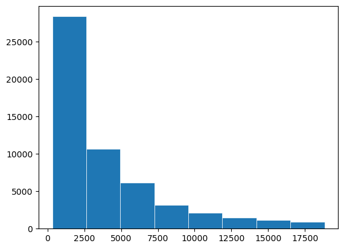

```python
import matplotlib.pyplot as plt
fig, ax= plt.subplots()
ax.hist(df['price'],bins=8,linewidth=0.5,edgecolor="white")
plt.show()
```

This is a univariate analysis because it examines only one variable, which is the price column.

Box plot

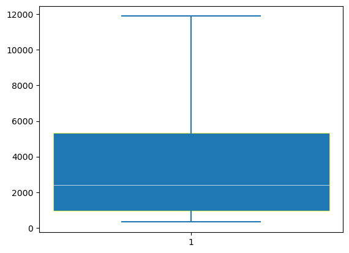

```python
fig, ax = plt.subplots()
VP = ax.boxplot(df["price"], widths=1.5, patch_artist=True,
                showmeans=False, showfliers=False,
                medianprops={"color": "white", "linewidth": 0.5},
                boxprops={"facecolor": "C0", "edgecolor": "yellow",
                          "linewidth": 0.5},
                whiskerprops={"color": "C0", "linewidth": 1.5},
                capprops={"color": "C0", "linewidth": 1.5})
```

This is a univariate analysis because it examines only one variable, which is the price column

SCATTER PLOT

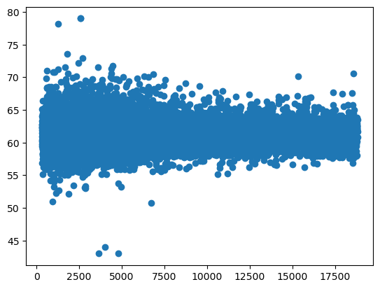

```python
import matplotlib.pyplot as plt
fig,ax=plt.subplots()
ax.scatter(df["price"],df["depth"])
plt.show()
```

This chart is a bivariate analysis because it involves two variables: price and depth. Using a scatter plot in Matplotlib, each point represents a pair of values where the x-axis shows the price amount and the y-axis shows the corresponding depth. The purpose of this chart is to observe any relationship or pattern between the two variables.

BAR CHART

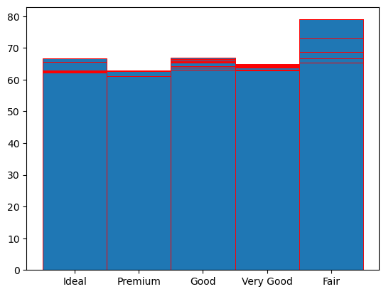

```python
import matplotlib.pyplot as plt
fig,ax=plt.subplots()
ax.bar(df["cut"],df["depth"],width=1,edgecolor="red",linewidth=0.7)
plt.show()
```

This is a bivariate chart because it uses two variables: cut and depth. In this bar chart created with Matplotlibss, the x-axis shows cut and the y-axis shows depth values. Each bar represents cut for a depth, but since all rows are plotted, the chart may look crowded

LABEL ENCODE

```python
from sklearn.preprocessing import LabelEncoder
le = LabelEncoder()

df['cut'] = le.fit_transform(df['cut'])
df['color'] = le.fit_transform(df['color'])
df['clarity'] = le.fit_transform(df['clarity'])
print(df)
```

```
       carat  cut  color  clarity  depth  table  price     x     y     z
0       0.23    2      1        3   61.5   55.0    326  3.95  3.98  2.43
1       0.21    3      1        2   59.8   61.0    326  3.89  3.84  2.31
2       0.23    1      1        4   56.9   65.0    327  4.05  4.07  2.31
3       0.29    3      5        5   62.4   58.0    334  4.20  4.23  2.63
4       0.31    1      6        3   63.3   58.0    335  4.34  4.35  2.75
...      ...  ...    ...      ...    ...    ...    ...   ...   ...   ...
53935   0.72    2      0        2   60.8   57.0   2757  5.75  5.76  3.50
53936   0.72    1      0        2   63.1   55.0   2757  5.69  5.75  3.61
53937   0.70    4      0        2   62.8   60.0   2757  5.66  5.68  3.56
53938   0.86    3      4        3   61.0   58.0   2757  6.15  6.12  3.74
53939   0.75    2      0        3   62.2   55.0   2757  5.83  5.87  3.64

[53940 rows x 10 columns]
```

LabelEncoder is used to convert categorical text data (like “cut”, “color”, “clarity”) into numeric values (0, 1, 2). It helps turn non-numeric labels into numbers, making the dataset suitable for training models.

```python
x=df.drop(columns=["price"],axis=1)
print(x)

y=df["price"]
print(y)
```

```
       carat  cut  color  clarity  depth  table     x     y     z
0       0.23    2      1        3   61.5   55.0  3.95  3.98  2.43
1       0.21    3      1        2   59.8   61.0  3.89  3.84  2.31
2       0.23    1      1        4   56.9   65.0  4.05  4.07  2.31
3       0.29    3      5        5   62.4   58.0  4.20  4.23  2.63
4       0.31    1      6        3   63.3   58.0  4.34  4.35  2.75
...      ...  ...    ...      ...    ...    ...   ...   ...   ...
53935   0.72    2      0        2   60.8   57.0  5.75  5.76  3.50
53936   0.72    1      0        2   63.1   55.0  5.69  5.75  3.61
53937   0.70    4      0        2   62.8   60.0  5.66  5.68  3.56
53938   0.86    3      4        3   61.0   58.0  6.15  6.12  3.74
53939   0.75    2      0        3   62.2   55.0  5.83  5.87  3.64

[53940 rows x 9 columns]
0         326
1         326
2         327
3         334
4         335
         ...
53935    2757
53936    2757
53937    2757
53938    2757
53939    2757
Name: price, Length: 53940, dtype: int64
```

This code separates our data into inputs and output. x contains all columns except "price", while y contains only the "price" column .

```python
from sklearn.model_selection import train_test_split
x_train,x_test,y_train,y_test=train_test_split(x,y, test_size=0.2, random_state=42)
print(f"x_train{x_train}")
print(f"x_test{x_test}")
print(f"y_train{y_train}")
print(f"y_test{y_test}")
```

```
x_train       carat  cut  color  clarity  depth  table     x     y     z
26546   2.01    1      2        3   58.1   64.0  8.23  8.19  4.77
9159    1.01    4      1        3   60.0   60.0  6.57  6.49  3.92
14131   1.10    3      4        5   62.5   58.0  6.59  6.54  4.10
15757   1.50    1      1        3   61.5   65.0  7.21  7.17  4.42
24632   1.52    4      3        4   62.1   57.0  7.27  7.32  4.53
...      ...  ...    ...      ...    ...    ...   ...   ...   ...
11284   1.05    4      5        5   62.4   59.0  6.48  6.51  4.05
44732   0.47    2      0        4   61.0   55.0  5.03  5.01  3.06
38158   0.33    4      2        1   60.3   58.0  4.49  4.46  2.70
860     0.90    3      6        2   62.8   59.0  6.13  6.03  3.82
15795   1.14    3      2        2   60.4   58.0  6.82  6.79  4.11

[43152 rows x 9 columns]
x_test       carat  cut  color  clarity  depth  table     x     y     z
```

[output cut: 37 more lines]

This code splits the data into training (80%) and testing (20%) sets using train_test_split. The training data is used to build the model, and the testing data is used to check its performance on new data.

```
                                                    MODEL BULIDING
```

LINEAR REGRESSION MODEL

```python
from sklearn.linear_model import LinearRegression
model=LinearRegression()
model.fit(x_train,y_train)
predictions=model.predict(x_test)
accuracy=model.score(x_test,y_test)
print(f"predictions{predictions}")
print(f"accuracy {accuracy}")
```

```
predictions[ 363.6466877  3355.93230836 2139.56606421 ...  619.0375529  7788.02953409
 4643.63909957]
accuracy 0.8851397433679632
```

This code creates a Linear Regression model, trains it using the training data (x_train, y_train), and then uses it to predict values for the test data (x_test). The score() gives the model’s accuracy (how well it fits the data). This process is needed to build a prediction model and evaluate how well it works on unseen data.

```python
from sklearn.metrics import mean_squared_error, r2_score

mse = mean_squared_error(y_test, predictions)
r2 = r2_score(y_test,predictions)

print(f"MSE: {mse}")
print(f"R2 Score: {r2}")
```

```
MSE: 1825912.9915253473
R2 Score: 0.8851397433679632
```

DECISION TREE MODEL

```python
from sklearn.tree import DecisionTreeRegressor

model = DecisionTreeRegressor()
model.fit(x_train, y_train)
predictions = model.predict(x_test)
accuracy = model.score(x_test, y_test)

print(f"predictions {predictions}")
print(f"accuracy {accuracy}")
```

```
predictions [ 559. 2321. 1238. ...  755. 8629. 3604.]
accuracy 0.9672957681148588
```

This code creates a Decision Tree model, trains it using the training data, and then predicts values for the test data. The score() shows how well the model performs (R² score). This is needed to build a different type of prediction model and check its accuracy on unseen data.

```python
from sklearn.metrics import mean_squared_error, r2_score

mse = mean_squared_error(y_test, predictions)
r2 = r2_score(y_test, predictions)

print(f"MSE: {mse}")
print(f"R2 Score: {r2}")
```

```
MSE: 519893.33497868
R2 Score: 0.9672957681148588
```